# 02_Class_Activity

Author

Bill Perry

# In class activity 1:

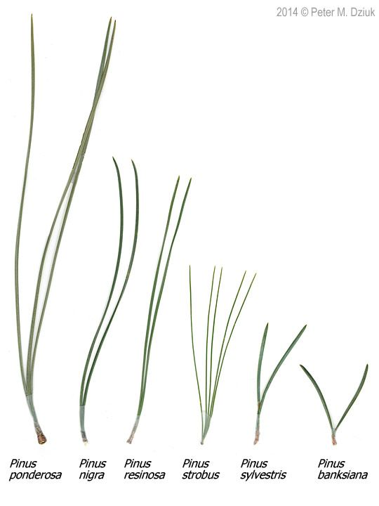

# What did we do last time?

- How to set up a project
- How to create a quarto markdown file
- How to add code at the start to make it work better
- How to load libraries `library(tidyverse)`
- What the `<-` is and what it does
- How to read in a file - csv and excel - `name_df <- read_csv("data/file.csv")`
- How to graph data -

  ```r
  ggplot(name_df, aes(x_variable, y_variable, color = categorical_variable)) +
  #      dataframe, aesthetics(x and y variables, mapping of color or fill or shape) +
    geom_point() +
  # this it the geometry you want and can add more layers like
    geom_line()
  ```

# Objectives and goals

- Data wrangling and setting up a project
  - variable names - directory names - object names
  - can be anything you want - choose wisely young padawan
- How can we save the data we modify and where to save it?
- Why is it important to use the same names for variables?
  - can reuse code
  - clearer names and use
- What is the `%>%` or the `|>` - the pipe will make you happy
- Summarize data to a new dataframe
- Improve graphs
  - adding labels
  - doing summary plots
  - getting fancy
- combining or splittig dataframes - the bind_rows(1,2)
- Do we go wide to long and back again? We will see

[figure not shown]

# Before we start

1. What data do we have
   1. what is the controlled vocabulary?
   2. are there units?
2. What is the directory structure?
3. Do we have a metadata file?
4. Is the data entered in a tidy format?
5. What are we missing?

# Now lets create a new quarto file in the system I set up

- note I usually use this sort of system in an r_projects directory
- I have redone it for the class to organize all of the terms data
- you should try making some of your own projects

[figure not shown]

## In RStudio:

1. click `file` - `open project` and select the `2025_UMD_BioStats_Student_Code.Rproj` file or double click on it in the finder or data explorer.
2. your screen will now change as RStudio knows where home is

[figure not shown]

3. Note that in the upper right you will see `2025_UMD_BioStats_Student_Code` so you know you are in the right spot
4. Now click File - New File - Quarto File

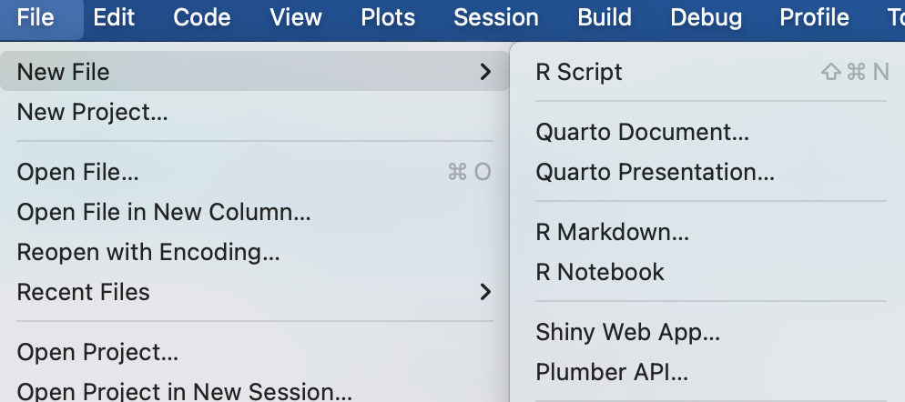

5. Create a file that starts with `02_` and then something that will help you know what is going on like `02_class_activity_in_class.qmd`
6. Now this file thinks this is home.
7. So I usually copy stuff for the header from another file as its just too hard to remember all this…

```r
---
title: "Title of your file" # Title of the file
author: "Your Name" # who you are
format: # this is the formats that it will render to
  html:
    toc: false # not table of contents
    default: true
    embed-resources: true # makes everything go into the html file
    self-contained: true # also makes self contained
editor: visual # type of editing
project:
  execute-dir: project # where it will look for files
execute:
  keep-md: true # retains the images when you start again
  cache: true # also heps reatain images and code
---
```

# Now to load the libraries

```r
# install packages -----
# install.packages("readxl")
# install.packages("tidyverse")

# # we will install a few new libraries
# install.packages("skimr")
```

Each script you run from then on you will load the libraries from within the package.

```r
# Load the libraries ----
library(readxl) # allows to read in excel files
library(tidyverse) # provides utilities seen in console
library(skimr) # provide summary stats
library(here) # you dont need this one - just me in this html file
```

# Loading files

Now like we did before with x and y we will do this with a spreadsheet from a CSV file or excel file

We are going to work with the same data we did in the last class.

# The Dataframe and variables

## The whole dataframe - wont show all

```r
p_df
```

```
# A tibble: 48 × 6
   date    group       n_s   wind  tree_no len_mm
   <chr>   <chr>       <chr> <chr>   <dbl>  <dbl>
 1 3/20/25 cephalopods n     lee         1     20
 2 3/20/25 cephalopods n     lee         1     21
 3 3/20/25 cephalopods n     lee         1     23
 4 3/20/25 cephalopods n     lee         1     25
 5 3/20/25 cephalopods n     lee         1     21
 6 3/20/25 cephalopods n     lee         1     16
 7 3/20/25 cephalopods s     wind        1     15
 8 3/20/25 cephalopods s     wind        1     16
 9 3/20/25 cephalopods s     wind        1     14
10 3/20/25 cephalopods s     wind        1     17
# ℹ 38 more rows
```

## The top of the datafame to see what it looks like

```r
head(p_df)
```

```
# A tibble: 6 × 6
  date    group       n_s   wind  tree_no len_mm
  <chr>   <chr>       <chr> <chr>   <dbl>  <dbl>
1 3/20/25 cephalopods n     lee         1     20
2 3/20/25 cephalopods n     lee         1     21
3 3/20/25 cephalopods n     lee         1     23
4 3/20/25 cephalopods n     lee         1     25
5 3/20/25 cephalopods n     lee         1     21
6 3/20/25 cephalopods n     lee         1     16
```

```r
# tail(p_df) # the bottom
```

## How to look at one variable

```r
p_df$group # name of dataframe $ varaible
```

```
 [1] "cephalopods" "cephalopods" "cephalopods" "cephalopods" "cephalopods"
 [6] "cephalopods" "cephalopods" "cephalopods" "cephalopods" "cephalopods"
[11] "cephalopods" "cephalopods" "salmon"      "salmon"      "salmon"
[16] "salmon"      "salmon"      "salmon"      "salmon"      "salmon"
[21] "salmon"      "salmon"      "salmon"      "salmon"      "crayfish"
[26] "crayfish"    "crayfish"    "crayfish"    "crayfish"    "crayfish"
[31] "crayfish"    "crayfish"    "crayfish"    "crayfish"    "crayfish"
[36] "crayfish"    "snail"       "snail"       "snail"       "snail"
[41] "snail"       "snail"       "snail"       "snail"       "snail"
[46] "snail"       "snail"       "snail"
```

# Plotting

## XY Plot with dodged points

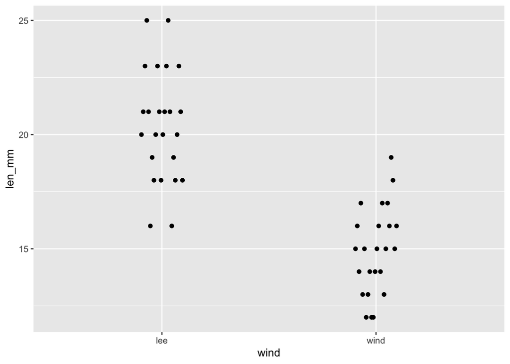

```r
knitr::opts_chunk$set(
  comment = '', fig.width = 4, fig.height = 3)

ggplot(data = p_df, aes(x=wind, y=len_mm)) +
  geom_point(position = position_dodge2(width=0.2) )
```

```r
# this dodges the points # position_dodge2 or can use position_dodge depending on grouping
```

## Histogram Color with Bins

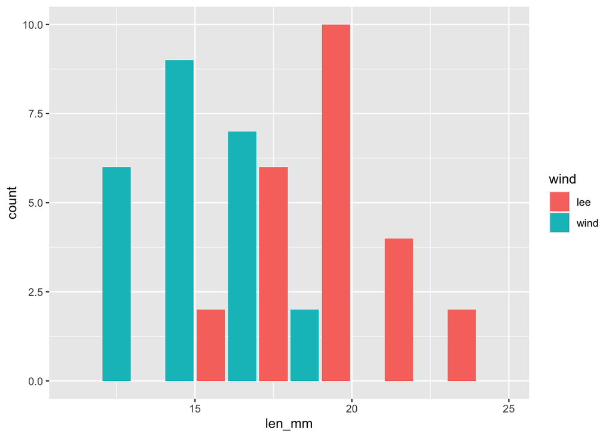

```r
knitr::opts_chunk$set(
  comment = '', fig.width = 4, fig.height = 3)

ggplot(data = p_df, aes(x=len_mm, fill = wind)) +
  geom_histogram( binwidth = 2,
# sets the width in units of the bins - try different nubmers
   position = position_dodge2(width = 0.5))
```

## Box and Whisker Plots

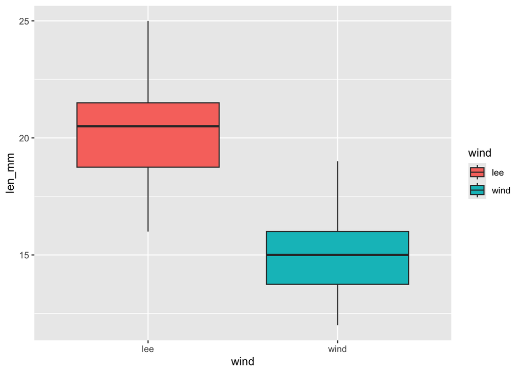

```r
knitr::opts_chunk$set(
  comment = '', fig.width = 4, fig.height = 3)

ggplot(data = p_df, aes(x=wind, y=len_mm, fill = wind)) + geom_boxplot()
```

# How to save plots

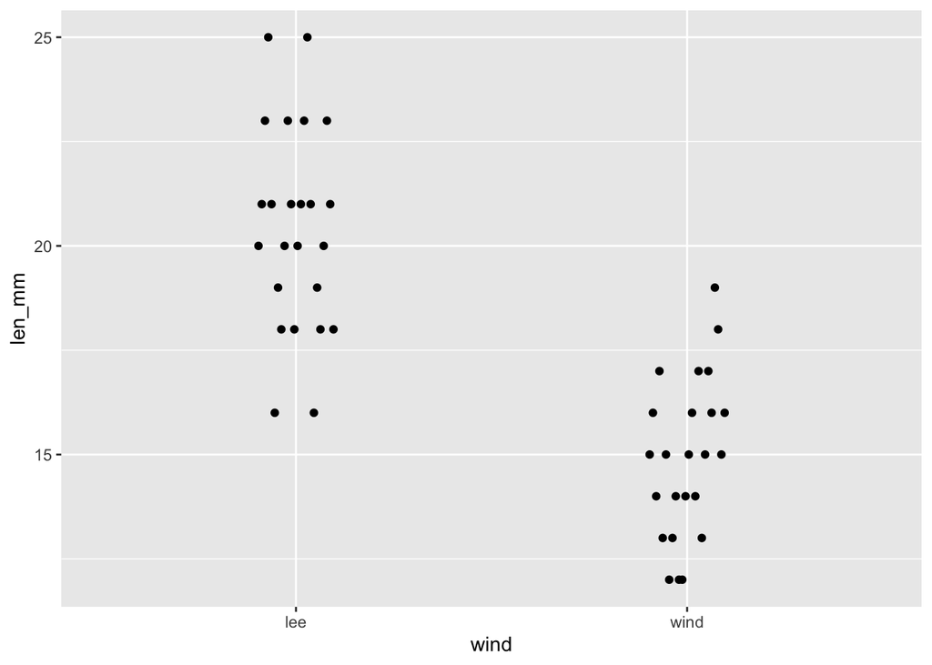

```r
xy_plot <- ggplot(data = p_df, aes(x=wind, y=len_mm)) +
  geom_point(position = position_dodge2(width=0.2) )
xy_plot
```

we can save this plot by typing

```r
ggsave(xy_plot, # name of the plot you called it
       file = "figures/xy_plot.pdf", # type of file you want - pdf is good
       units = "in", # what are the units you want to measure in
       width = 6, height = 6) # dimensions - not if large the fonts need to be adjusted
```

The file should be in the figures directory

# Now lets make the graph prettier

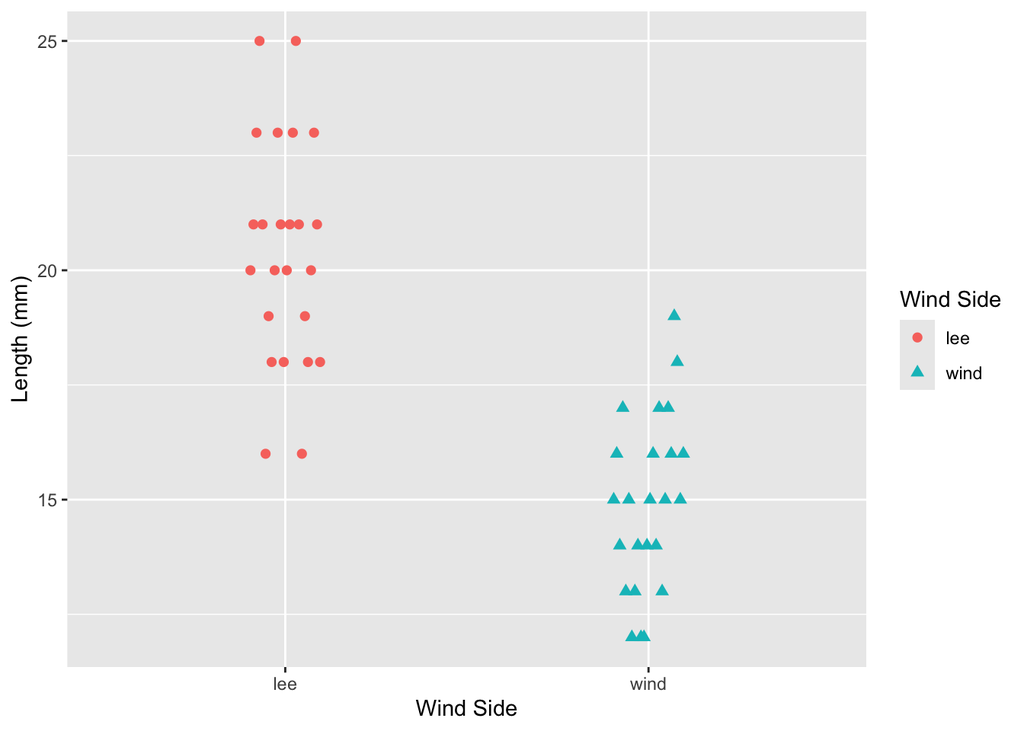

```r
xy_plot <- ggplot(data = p_df, aes(x=wind, y=len_mm, color = wind, shape = wind)) +
  geom_point(
    size = 2,
    position = position_dodge2(width=0.2)) +
  labs(x="Wind Side", y = "Length (mm)", color = "Wind Side", shape = "Wind Side")
xy_plot
```

## we can also add themes

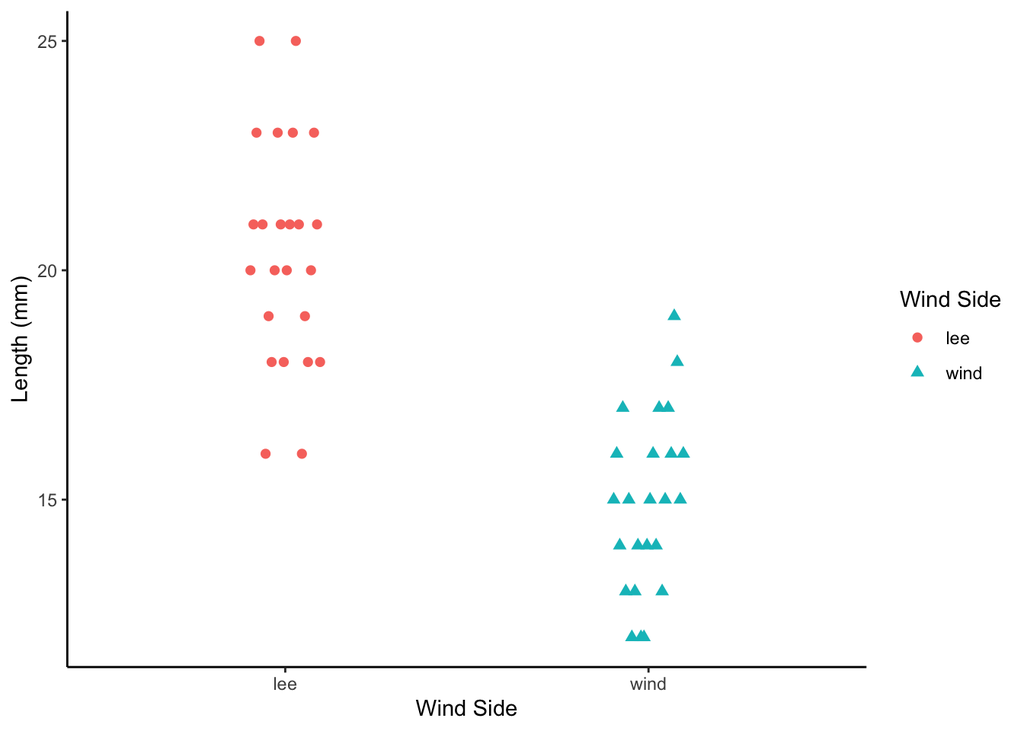

```r
xy_plot <- ggplot(data = p_df, aes(x=wind, y=len_mm, color = wind, shape = wind)) +
  geom_point(
    size = 2,
    position = position_dodge2(width=0.2)) +
  labs(x="Wind Side", y = "Length (mm)", color = "Wind Side", shape = "Wind Side") +
  theme_classic()
xy_plot
```

## change the scale by zooming in

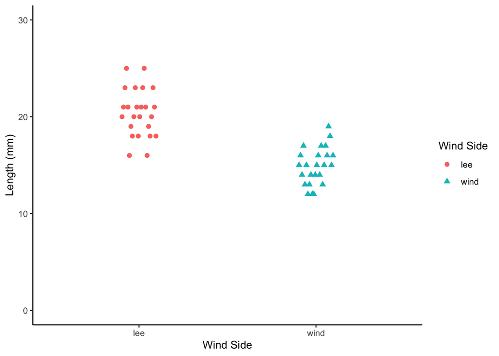

```r
xy_plot <- ggplot(data = p_df, aes(x=wind, y=len_mm, color = wind, shape = wind)) +
  geom_point(
    size = 2,
    position = position_dodge2(width=0.2)) +
  labs(x="Wind Side", y = "Length (mm)", color = "Wind Side", shape = "Wind Side") +
  theme_classic() +
  coord_cartesian(ylim = c(0,30))
xy_plot
```

# Summarizing data - two ways

lets say we want to summarize the data and need to get n, means, standard deviation, standard error

We could do

```r
mean(p_df$len_mm, na.rm = TRUE) # removes missing values
```

```
[1] 17.66667
```

```r
length(p_df$len_mm)
```

```
[1] 48
```

- the length counts missing and non-missing data
- however this would get old if we had to do this for everything and then to do it for the different groupings - lee and windward…

## we need to learn to pipe things

- the dataframe –> pipe command that feed the dataframe into –> next command

```r
p_df %>% summarize(mean_length = mean(len_mm, na.rm = TRUE))
```

```
# A tibble: 1 × 1
  mean_length
        <dbl>
1        17.7
```

## What is cool is we can do a lot of different things now

```r
p_df %>%
  summarize(
    mean_length = mean(len_mm, na.rm = TRUE),
    sd_length = sd(len_mm, na.rm = TRUE),
    n_length = n())
```

```
# A tibble: 1 × 3
  mean_length sd_length n_length
        <dbl>     <dbl>    <int>
1        17.7      3.53       48
```

## Super cool code in case there are missing values

```r
p_df %>%
  summarize(
    mean_length = mean(len_mm, na.rm = TRUE),
    sd_length = sd(len_mm, na.rm = TRUE),
    n_length = sum(!is.na(len_mm)))
```

```
# A tibble: 1 × 3
  mean_length sd_length n_length
        <dbl>     <dbl>    <int>
1        17.7      3.53       48
```

## what else do we want to know though

- we want to know the mean and such for each group of the treatements
- how could we do this?
  - we need to add a command - `group_by(wind)
  - but how can we do this for this code?

```r
p_df %>%
  summarize(
    mean_length = mean(len_mm, na.rm = TRUE),
    sd_length = sd(len_mm, na.rm = TRUE),
    n_length = sum(!is.na(len_mm)))
```

```
# A tibble: 1 × 3
  mean_length sd_length n_length
        <dbl>     <dbl>    <int>
1        17.7      3.53       48
```

## what if we wanted to save this output

what else do we need to do to save the output

# Using Skimr

```r
p_df %>% skim()
```

Data summary

| Name | Piped data |
| --- | --- |
| Number of rows | 48 |
| Number of columns | 6 |
| _______________________ |  |
| Column type frequency: |  |
| character | 4 |
| numeric | 2 |
| ________________________ |  |
| Group variables | None |

**Variable type: character**

| skim_variable | n_missing | complete_rate | min | max | empty | n_unique | whitespace |
| --- | --- | --- | --- | --- | --- | --- | --- |
| date | 0 | 1 | 7 | 7 | 0 | 1 | 0 |
| group | 0 | 1 | 5 | 11 | 0 | 4 | 0 |
| n_s | 0 | 1 | 1 | 1 | 0 | 2 | 0 |
| wind | 0 | 1 | 3 | 4 | 0 | 2 | 0 |

**Variable type: numeric**

| skim_variable | n_missing | complete_rate | mean | sd | p0 | p25 | p50 | p75 | p100 | hist |
| --- | --- | --- | --- | --- | --- | --- | --- | --- | --- | --- |
| tree_no | 0 | 1 | 2.50 | 1.13 | 1 | 1.75 | 2.5 | 3.25 | 4 | ▇▇▁▇▇ |
| len_mm | 0 | 1 | 17.67 | 3.53 | 12 | 15.00 | 17.5 | 20.25 | 25 | ▆▇▅▆▃ |

Back to top